# STATS 769 Lab 01

Chase Robertson

2022-07-27

# The Dataset

For this short project we’ll use a Vehicle Imports subset of the [Overseas merchandise trade dataset](https://www.stats.govt.nz/large-datasets/csv-files-for-download/overseas-merchandise-trade-datasets) as provided by Stats NZ. This can give us insight into Aotearoa New Zealand’s vehicle trade over the years, and includes the following variables:

- Month
- Harmonised System Code
- Harmonised System Description
- Unit Qty
- Country
- Imports vfd ($NZD value for duty)
- Imports cif ($NZD cost, insurance, and freight)
- Imports Qty
- Status

# Tasks

## Unix

1. Create lab01 directory, and navigate to that directory

```bash
mkdir lab01
cd lab01
```

2. Show info about all data files inc. size in bytes

```bash
ls -l vehicles-*.csv
```

3. Number of lines in vehicles-2020.csv

```bash
wc -l vehicles-2020.csv
```

4. Extract records with specific HSC code to a new file and show number of lines

```bash
grep 8703231915 vehicles-*.csv > car-imports.data
wc -l car-imports.data
```

5. Get total count for all HS codes and print greatest 5

```bash
cut -d',' -f2 vehicles-*.csv | sort | uniq -c | sort | tail -5
```

6. Create new csv file with vehicles matching the listed HS codes

```bash
head -1 vehicles-2000.csv > new-car-imports.csv
RAW="8703218006, 8703228003, 8703238003, 8703248003, 8703211915, 8703221915, 8703231915, 8703241915"
HSC=$(sed 's/, /|/g' <<< $RAW)
egrep -h $HSC vehicles-*.csv >> new-car-imports.csv
```

## Import

7. Read the previously created file into R

```r
cars <- read.csv("new-car-imports.csv")
str(cars)
```

```
## 'data.frame':    9451 obs. of  9 variables:
##  $ Month                        : int  200001 200001 200001 200001 200001 200001 200001 200001 200001 200001 ...
##  $ Harmonised.System.Code       : num  8.7e+09 8.7e+09 8.7e+09 8.7e+09 8.7e+09 ...
##  $ Harmonised.System.Description: Factor w/ 9 levels "Vehicles; spark-ignition internal combustion reciprocating piston engine, cylinder capacity exceeding 1000cc bu"| __truncated__,..: 4 1 1 1 1 1 2 2 2 2 ...
##  $ Unit.Qty                     : Factor w/ 1 level "NMB": 1 1 1 1 1 1 1 1 1 1 ...
##  $ Country                      : Factor w/ 43 levels "Australia","Austria",..: 19 36 11 42 18 19 1 3 12 36 ...
##  $ Imports...NZD.vfd.           : Factor w/ 9416 levels "1,001,609","1,002,293",..: 6007 1910 7803 6139 7858 68 4419 279 5840 8410 ...
##  $ Imports...NZD.cif.           : Factor w/ 9429 levels "1,000,202","1,000,659",..: 6111 2084 8288 6419 8238 246 4479 387 6470 8744 ...
##  $ Imports.Qty                  : Factor w/ 1040 levels "1","1,000","1,001",..: 664 200 597 519 743 975 238 725 254 299 ...
##  $ Status                       : Factor w/ 2 levels "Final","Provisional": 1 1 1 1 1 1 1 1 1 1 ...
```

## Clean

8. Improve colnames, convert numeric columns, and create Date column

```r
names(cars) <- c("Month", "HSC", "HSDescription", "Unit", "Country",
                 "VFD", "CIF", "Quantity", "Status")
num_cols = c("VFD", "CIF", "Quantity")
cars[num_cols] <- lapply(cars[num_cols],
                        function(x) {as.numeric(gsub(",", "", x))})
cars$Date <- as.Date(paste0(cars$Month, "01"), format="%Y%m%d")
str(cars)
```

```
## 'data.frame':    9451 obs. of  10 variables:
##  $ Month        : int  200001 200001 200001 200001 200001 200001 200001 200001 200001 200001 ...
##  $ HSC          : num  8.7e+09 8.7e+09 8.7e+09 8.7e+09 8.7e+09 ...
##  $ HSDescription: Factor w/ 9 levels "Vehicles; spark-ignition internal combustion reciprocating piston engine, cylinder capacity exceeding 1000cc bu"| __truncated__,..: 4 1 1 1 1 1 2 2 2 2 ...
##  $ Unit         : Factor w/ 1 level "NMB": 1 1 1 1 1 1 1 1 1 1 ...
##  $ Country      : Factor w/ 43 levels "Australia","Austria",..: 19 36 11 42 18 19 1 3 12 36 ...
##  $ VFD          : num  410242 125408 662198 44266 68133 ...
##  $ CIF          : num  432496 137791 730063 49558 72299 ...
##  $ Quantity     : num  42 11 36 3 5 85 144 48 159 2 ...
##  $ Status       : Factor w/ 2 levels "Final","Provisional": 1 1 1 1 1 1 1 1 1 1 ...
##  $ Date         : Date, format: "2000-01-01" "2000-01-01" ...
```

## Explore

9. Create barplot of total VFD per country

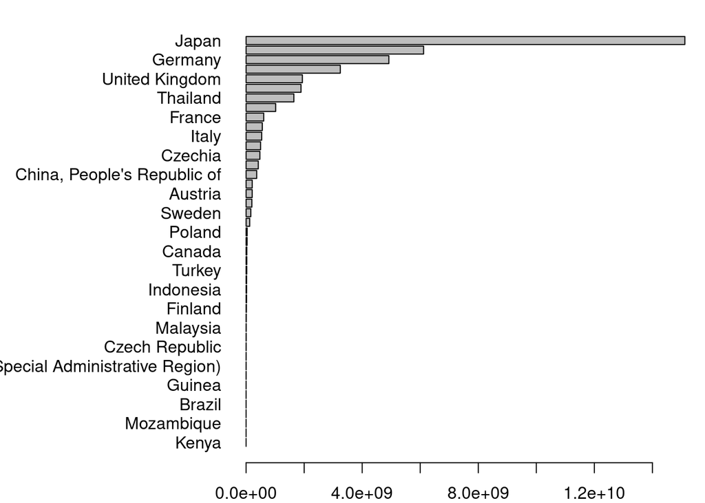

```r
tab <- tapply(cars$VFD, cars$Country, sum)
par(mar=c(2,12,1,1))
barplot(tab[order(tab)], horiz=T, las=1)
```

The above plot is too crowded, and heavy-tailed, so we plot again on a log scale with the number of countries shown reduced to 10.

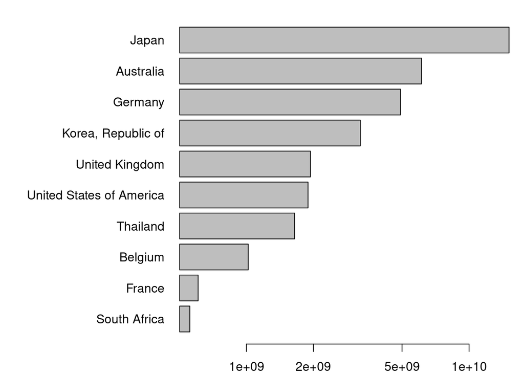

```r
tab <- tapply(cars$VFD, cars$Country, sum)
par(mar=c(2,12,1,1))
barplot(tail(tab[order(tab)], 10), horiz=T, las=1, log="x")
```

10. Compute and plot monthly import value per HS code over time

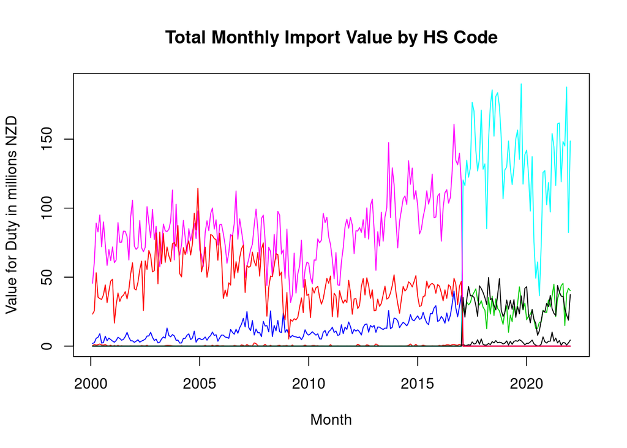

```r
hsc <- xtabs(VFD ~ Month + HSC, data=cars) / 1e6
matplot(hsc, type='l', lty=1, xaxt="n", xlab="Month",
        ylab="Value for Duty in millions NZD",
        main="Total Monthly Import Value by HS Code")
axis(1, at=seq(0, 250, by=60), labels=seq(2000, 2020, by=5))
```

Something major happened in 2017 - multiple HS codes’ VFD values either appear out of nowhere, or suddenly drop to 0. The trendlines seem to continue normally enough, but the colors have changed! This suggests that the HS code specification may have changed in 2017 - the same engines are represented by different codes within each date range.

```r
descs <- unique(cars$HSDescription)
descs[1]
```

```
## [1] Vehicles; spark-ignition internal combustion reciprocating piston engine, cylinder capacity not exceeding 1000cc, new motor cars, assembled
## 9 Levels: Vehicles; spark-ignition internal combustion reciprocating piston engine, cylinder capacity exceeding 1000cc but not exceeding 1500cc, new motor cars, assembled ...
```

```r
descs[5]
```

```
## [1] Vehicles; with only spark-ignition internal combustion reciprocating piston engine, cylinder capacity not over 1000cc, new motor cars, assembled
## 9 Levels: Vehicles; spark-ignition internal combustion reciprocating piston engine, cylinder capacity exceeding 1000cc but not exceeding 1500cc, new motor cars, assembled ...
```

By the looks of it, some re-coding was done to explicitly separate hybrid vehicles - from “Vehicles; spark-ignition” to “Vehicles; with only spark-ignition”. I would propose creating a new copy of the dataset with the old HS codes converted to their new counterpart, such that each engine category has one continuous timeline of data.

## Model

11. Narrowing the scope to German imports, a mean model and linear model are fit to the first 90% of Date and used to predict “future” VFD.

```r
# narrow scope to Germany, scale vfd to millions NZD, sort by Month
germany <- aggregate(VFD ~ Date, data=subset(cars, Country == 'Germany'), sum)
germany$VFD <- germany$VFD / 1e6
germany <- germany[order(germany$Date),]

# reserve final 10% for testing
n <- nrow(germany)
pivot <- floor(n * 0.9)
train <- germany[1:pivot,]
test <- germany[-(1:pivot),]

mean_model <- mean(train$VFD)
mean_pred <- rep(mean_model, nrow(test))

linear_model <- lm(VFD ~ Date, data=train)
linear_pred <- predict(linear_model, test)

rmse <- function(actual, predicted) {
    sqrt(mean((actual - predicted) ^ 2))
}

cat("RMSE for mean:", fill=T)
```

```
## RMSE for mean:
```

```r
rmse(test$VFD, mean_pred)
```

```
## [1] 8.379609
```

```r
cat("RMSE for linear model:", fill=T)
```

```
## RMSE for linear model:
```

```r
rmse(test$VFD, linear_pred)
```

```
## [1] 11.52066
```

Plot of VFD over time, with each model plotted, and an indication of where train/test split occurs.

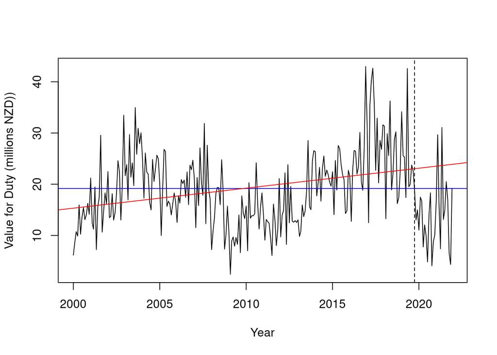

```r
plot(VFD ~ Date, data=germany, type='l',
     xlab='Year', ylab='Value for Duty (millions NZD))')
abline(h=mean_model, col='blue')
abline(linear_model, col='red')
abline(v=test$Date[1], lty=2)
```

The linear model is not very sensible, as it performs worse than simple mean prediction, and is not nearly flexible enough to capture seasonal or year-over-year trends. The increase in imports between 2015 and 2019 draws the line up to positive slope, but the trend in the test set is not all that positive.

# Summary

In this project, we took a look at Aotearoa New Zealand’s vehicle imports over time. It provided a good opportunity to practice some Linux shell commands, data cleaning, data analysis and visualisation, and simple modeling. The data were discovered to contain interesting quirks like re-coded vehicle categories. A simple linear model was discovered not to model imports from Germany very well, which is not surprising. Further research directions might include confirming and clarifying the vehicle re-coding hypothesis with information from Stats NZ, and fitting more flexible models or making better use of the other variables included in the dataset.